# Part 5-How many factors-3

# Test the model with two factors

```r
Model.2 <- '#latent variable definition
            QRP =~ QAttention + QSupervision + QResDesign + QUnfairRev
                 + QUnsubstClaims + QCiteSource + QResNotes + QConcealDetails
                 + QNoReSubmit + QConcealFlaws + QSelectCites
                 + RR_sum
            RRP =~ RDisclFunds + RCorrectPub + RAuthorship + ROpenData
                 + RKeepRecord + RPreReg + RDataManage + ROpenAccess
                 + RCiteSource + ROpenCode + RErrorCheck

            #variance and covariance
            RDisclFunds ~~ RAuthorship
            RCorrectPub ~~ RErrorCheck
            ROpenData ~~ ROpenCode

'
fit.model.2 <- cfa(Model.2, data = complete(d50[[1]]), estimator = "WLSMV", std.lv=TRUE)
summary(fit.model.2, fit.measures = TRUE)
```

```
## lavaan 0.6-9 ended normally after 43 iterations
##
##   Estimator                                       DWLS
##   Optimization method                           NLMINB
##   Number of model parameters                        50
##
##   Number of observations                          6813
##
## Model Test User Model:
##                                               Standard      Robust
##   Test Statistic                              3970.593    4231.589
##   Degrees of freedom                               226         226
##   P-value (Chi-square)                           0.000       0.000
##   Scaling correction factor                                  0.946
##   Shift parameter                                           35.968
##        simple second-order correction
##
## Model Test Baseline Model:
##
##   Test statistic                             23249.483   14902.057
##   Degrees of freedom                               253         253
##   P-value                                        0.000       0.000
##   Scaling correction factor                                  1.570
##
## User Model versus Baseline Model:
##
##   Comparative Fit Index (CFI)                    0.837       0.727
##   Tucker-Lewis Index (TLI)                       0.818       0.694
##
##   Robust Comparative Fit Index (CFI)                            NA
##   Robust Tucker-Lewis Index (TLI)                               NA
##
## Root Mean Square Error of Approximation:
##
##   RMSEA                                          0.049       0.051
##   90 Percent confidence interval - lower         0.048       0.050
##   90 Percent confidence interval - upper         0.051       0.052
##   P-value RMSEA <= 0.05                          0.795       0.107
##
##   Robust RMSEA                                                  NA
```

[output cut: 64 more lines]

```
##    .QSelectCites      2.061    0.053   38.830    0.000
##    .RR_sum            0.314    0.006   55.832    0.000
##    .RDisclFunds       2.680    0.067   39.716    0.000
##    .RCorrectPub       5.120    0.046  111.760    0.000
##    .RAuthorship       2.434    0.048   50.621    0.000
##    .ROpenData         2.583    0.050   51.478    0.000
##    .RKeepRecord       2.720    0.043   62.642    0.000
##    .RPreReg           3.654    0.052   70.719    0.000
##    .RDataManage       2.450    0.056   44.009    0.000
##    .ROpenAccess       2.638    0.048   55.068    0.000
##    .RCiteSource       0.875    0.038   23.098    0.000
##    .ROpenCode         3.509    0.046   76.154    0.000
##    .RErrorCheck       1.159    0.036   32.404    0.000
##     QRP               1.000
##     RRP               1.000
```

The CFI is 0.84.

# Five modifications to improve Model 2

```r
modificationindices(fit.model.2, sort. = TRUE, maximum.number = 5)
```

```
##             lhs op         rhs      mi    epc sepc.lv sepc.all sepc.nox
## 202   QResNotes ~~ RKeepRecord 309.399 -0.572  -0.572   -0.269   -0.269
## 61          QRP =~ RCiteSource 231.781 -0.215  -0.215   -0.202   -0.202
## 190 QCiteSource ~~ RCiteSource 218.057 -0.171  -0.171   -0.326   -0.326
## 67          RRP =~  QUnfairRev 201.983 -0.120  -0.120   -0.194   -0.194
## 63          QRP =~ RErrorCheck 168.371 -0.237  -0.237   -0.182   -0.182
```

```r
Model.2.modi <- '#latent variable definition
            QRP =~ QAttention + QSupervision + QResDesign + QUnfairRev
                 + QUnsubstClaims + QCiteSource + QResNotes + QConcealDetails
                 + QNoReSubmit + QConcealFlaws + QSelectCites
                 + RR_sum
                 + RCiteSource + RErrorCheck
            RRP =~ RDisclFunds + RCorrectPub + RAuthorship + ROpenData
                 + RKeepRecord + RPreReg + RDataManage + ROpenAccess
                 + RCiteSource + ROpenCode + RErrorCheck
                 + QUnfairRev
            #variance and covariance
            RDisclFunds ~~ RAuthorship
            RCorrectPub ~~ RErrorCheck
            ROpenData ~~ ROpenCode
            QResNotes ~~ RKeepRecord
            QCiteSource ~~ RCiteSource

'
fit.model.2.modi <- cfa(Model.2.modi, data = complete(d50[[1]]), estimator = "WLSMV", std.lv=TRUE)
summary(fit.model.2.modi, fit.measures = TRUE)
```

```
## lavaan 0.6-9 ended normally after 47 iterations
##
##   Estimator                                       DWLS
##   Optimization method                           NLMINB
##   Number of model parameters                        55
##
##   Number of observations                          6813
##
## Model Test User Model:
##                                               Standard      Robust
##   Test Statistic                              2714.118    2963.142
##   Degrees of freedom                               221         221
##   P-value (Chi-square)                           0.000       0.000
##   Scaling correction factor                                  0.926
##   Shift parameter                                           33.491
##        simple second-order correction
##
## Model Test Baseline Model:
##
##   Test statistic                             23249.483   14902.057
##   Degrees of freedom                               253         253
##   P-value                                        0.000       0.000
##   Scaling correction factor                                  1.570
##
## User Model versus Baseline Model:
##
##   Comparative Fit Index (CFI)                    0.892       0.813
##   Tucker-Lewis Index (TLI)                       0.876       0.786
##
##   Robust Comparative Fit Index (CFI)                            NA
##   Robust Tucker-Lewis Index (TLI)                               NA
##
## Root Mean Square Error of Approximation:
##
##   RMSEA                                          0.041       0.043
##   90 Percent confidence interval - lower         0.039       0.041
##   90 Percent confidence interval - upper         0.042       0.044
##   P-value RMSEA <= 0.05                          1.000       1.000
##
##   Robust RMSEA                                                  NA
```

[output cut: 71 more lines]

```
##    .QSelectCites      2.037    0.053   38.334    0.000
##    .RR_sum            0.313    0.006   55.826    0.000
##    .RCiteSource       0.936    0.039   24.287    0.000
##    .RErrorCheck       1.264    0.034   36.707    0.000
##    .RDisclFunds       2.566    0.067   38.542    0.000
##    .RCorrectPub       5.052    0.048  105.304    0.000
##    .RAuthorship       2.443    0.048   50.874    0.000
##    .ROpenData         2.455    0.052   47.191    0.000
##    .RKeepRecord       2.741    0.044   62.846    0.000
##    .RPreReg           3.599    0.052   69.352    0.000
##    .RDataManage       2.399    0.056   43.084    0.000
##    .ROpenAccess       2.547    0.049   52.138    0.000
##    .ROpenCode         3.377    0.048   70.298    0.000
##     QRP               1.000
##     RRP               1.000
```

The CFI now is 0.89.

# Investigate model with three factors with explanatory factor analysis

```r
data.for.fa <- complete(d50[[1]])[c(118 : 140)]
hetcor(data.for.fa, ML = TRUE)$correlations
```

```
##                 RDisclFunds  RCorrectPub  RAuthorship    ROpenData  RKeepRecord
## RDisclFunds      1.00000000  0.185173431  0.220794470  0.174063878  0.093240217
## RCorrectPub      0.18517343  1.000000000  0.104591493  0.163707663  0.094630346
## RAuthorship      0.22079447  0.104591493  1.000000000  0.170972019  0.054883003
## ROpenData        0.17406388  0.163707663  0.170972019  1.000000000  0.230720907
## RKeepRecord      0.09324022  0.094630346  0.054883003  0.230720907  1.000000000
## RPreReg          0.12412600  0.144985014  0.030924898  0.180512264  0.171388143
## RDataManage      0.20452943  0.071706836  0.106594200  0.236339818  0.309775570
## ROpenAccess      0.28408242  0.121955638  0.185470673  0.232640539  0.057402664
## RCiteSource      0.22471224  0.100188966  0.252423118  0.162685189  0.099711384
## ROpenCode        0.16988551  0.167563963  0.137586667  0.414541098  0.124372932
## RErrorCheck      0.20594617  0.115600258  0.184795004  0.220882438  0.209882186
## QAttention       0.02394130  0.044448018 -0.059035918 -0.054138680 -0.070656898
## QSupervision     0.03535786  0.024371171 -0.020905262  0.012390463 -0.068165367
## QResDesign      -0.05528477  0.019275717 -0.151319932 -0.040870752 -0.061704328
## QUnfairRev      -0.17970624 -0.053211009 -0.160867974 -0.101351277 -0.034964113
## QUnsubstClaims  -0.04694321 -0.042130624 -0.138877395 -0.104733192 -0.081998250
## QCiteSource     -0.08607614 -0.028907790 -0.136648024 -0.074008917 -0.068918040
## QResNotes        0.04199868 -0.030418400 -0.045079111 -0.123828273 -0.281560969
## QConcealDetails -0.08517256 -0.029482922 -0.122987870 -0.099382446 -0.074627879
## QNoReSubmit      0.01618637  0.036999686 -0.032022308  0.023111727 -0.004086183
## QConcealFlaws    0.01436274  0.013710911 -0.081062743 -0.006054779 -0.005047753
## QSelectCites    -0.03553126  0.020278836 -0.109922970 -0.027544692 -0.048892708
## RR_sum          -0.03059861 -0.003002462 -0.008300036 -0.002139792 -0.022263699
##                     RPreReg  RDataManage  ROpenAccess RCiteSource    ROpenCode
## RDisclFunds      0.12412600  0.204529428  0.284082416  0.22471224  0.169885511
## RCorrectPub      0.14498501  0.071706836  0.121955638  0.10018897  0.167563963
## RAuthorship      0.03092490  0.106594200  0.185470673  0.25242312  0.137586667
## ROpenData        0.18051226  0.236339818  0.232640539  0.16268519  0.414541098
## RKeepRecord      0.17138814  0.309775570  0.057402664  0.09971138  0.124372932
## RPreReg          1.00000000  0.167816847  0.091175334  0.03626610  0.178681473
## RDataManage      0.16781685  1.000000000  0.126857951  0.14274482  0.190455505
## ROpenAccess      0.09117533  0.126857951  1.000000000  0.21524210  0.265465047
## RCiteSource      0.03626610  0.142744823  0.215242096  1.00000000  0.099024266
## ROpenCode        0.17868147  0.190455505  0.265465047  0.09902427  1.000000000
## RErrorCheck      0.08067293  0.246130684  0.187749121  0.35965742  0.128275986
## QAttention       0.01981239 -0.049557019 -0.006726046 -0.06931163 -0.015736685
## QSupervision     0.03958951 -0.034120868  0.017930734 -0.03350522  0.051883666
## QResDesign       0.02356951 -0.078388096 -0.037783646 -0.15233455 -0.001868452
## QUnfairRev      -0.03142069 -0.083728258 -0.137530420 -0.21914199 -0.050950554
```

[output cut: 65 more lines]

```
## RCiteSource     -0.037331085  -0.030839859 -0.117600802 -0.029929699
## ROpenCode        0.079891230   0.039430116  0.001966223  0.001594280
## RErrorCheck     -0.010427352  -0.034215355 -0.093795075 -0.030546739
## QAttention       0.072915742   0.151306843  0.144641639  0.014655587
## QSupervision     0.084566024   0.160035353  0.105302850  0.010688496
## QResDesign       0.109188164   0.152838538  0.193866122  0.023250924
## QUnfairRev       0.047243312   0.089082207  0.147682128  0.004859604
## QUnsubstClaims   0.131281553   0.157870261  0.236959709  0.034853538
## QCiteSource      0.065386709   0.104728878  0.202963579  0.026186514
## QResNotes        0.099359103   0.118970162  0.137643724  0.004136876
## QConcealDetails  0.128130316   0.141654489  0.182951404  0.044815880
## QNoReSubmit      1.000000000   0.105703896  0.171059737  0.030321138
## QConcealFlaws    0.105703896   1.000000000  0.196796634 -0.004104072
## QSelectCites     0.171059737   0.196796634  1.000000000  0.031924275
## RR_sum           0.030321138  -0.004104072  0.031924275  1.000000000
```

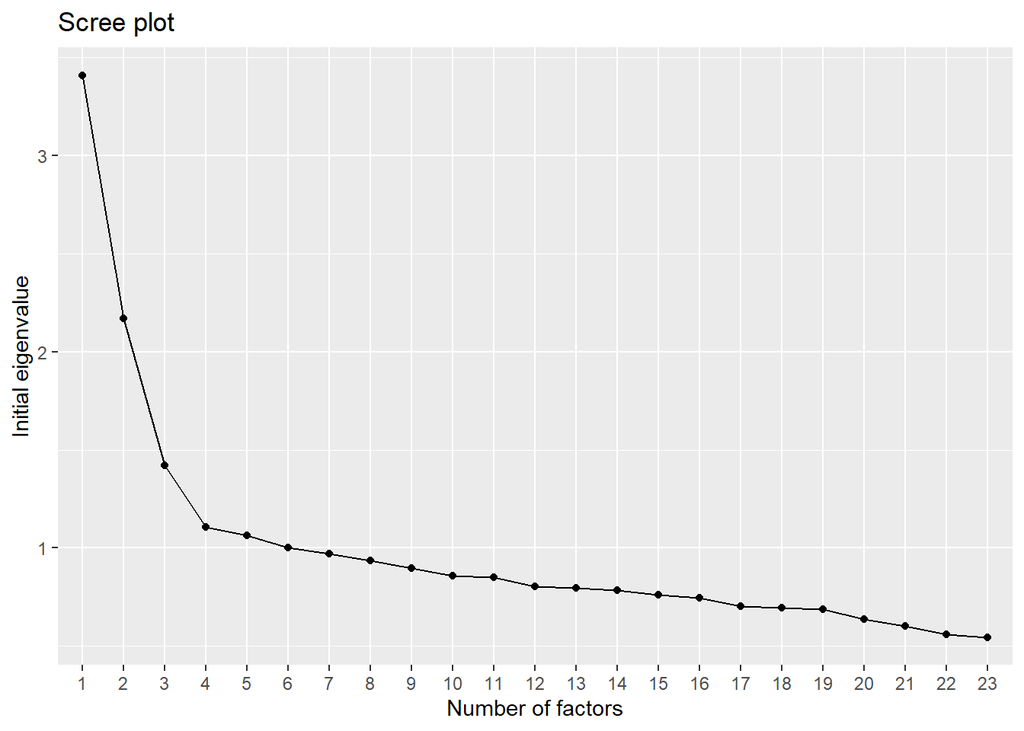

```r
fafit.free <- complete(d50[[1]]) %>% extract(c(118 : 140)) %>% hetcor(ML = TRUE) %>% use_series(correlations) %>% fa(., nfactors = 23, rotate = "none")
n.factors <- length(fafit.free$e.values)
data.frame(factor.num = as.factor(1 : length(fafit.free$e.values)),
           Eigenvalue = fafit.free$e.values) %>% ggplot(aes(x = factor.num,
                                                            y = Eigenvalue,
                                                            group = 1)) +
  geom_point() + geom_line() + xlab("Number of factors") +
  ylab("Initial eigenvalue") + ggtitle("Scree plot")
```

```r
efa.fit.3 <- complete(d50[[1]]) %>% extract(c(118 : 140)) %>% hetcor(ML = TRUE) %>% use_series(correlations) %>% fa(., nfactors = 3, rotate = "promax")
print(efa.fit.3)
```

```
## Factor Analysis using method =  minres
## Call: fa(r = ., nfactors = 3, rotate = "promax")
## Standardized loadings (pattern matrix) based upon correlation matrix
##                   MR2   MR1   MR3     h2   u2 com
## RDisclFunds      0.15  0.49  0.09 0.2701 0.73 1.3
## RCorrectPub      0.11  0.19  0.19 0.0994 0.90 2.6
## RAuthorship     -0.07  0.41  0.01 0.1878 0.81 1.1
## ROpenData        0.02  0.17  0.50 0.3387 0.66 1.2
## RKeepRecord     -0.21 -0.18  0.58 0.3138 0.69 1.5
## RPreReg          0.06  0.00  0.35 0.1256 0.87 1.1
## RDataManage     -0.08  0.08  0.42 0.2209 0.78 1.1
## ROpenAccess      0.13  0.44  0.12 0.2352 0.76 1.3
## RCiteSource     -0.12  0.53 -0.02 0.3210 0.68 1.1
## ROpenCode        0.15  0.19  0.41 0.2685 0.73 1.7
## RErrorCheck     -0.17  0.32  0.21 0.2649 0.74 2.3
## QAttention       0.41  0.07 -0.07 0.1585 0.84 1.1
## QSupervision     0.33  0.10 -0.03 0.0998 0.90 1.2
## QResDesign       0.46 -0.12  0.02 0.2540 0.75 1.1
## QUnfairRev       0.20 -0.35  0.06 0.1854 0.81 1.7
## QUnsubstClaims   0.46 -0.11 -0.04 0.2568 0.74 1.1
## QCiteSource      0.32 -0.30  0.06 0.2313 0.77 2.1
## QResNotes        0.49  0.21 -0.33 0.2893 0.71 2.2
## QConcealDetails  0.39 -0.15 -0.04 0.2107 0.79 1.3
## QNoReSubmit      0.27  0.03  0.05 0.0732 0.93 1.1
## QConcealFlaws    0.35  0.01  0.06 0.1210 0.88 1.1
## QSelectCites     0.39 -0.11  0.07 0.1860 0.81 1.2
## RR_sum           0.04 -0.03  0.01 0.0033 1.00 2.0
##
##                        MR2  MR1  MR3
## SS loadings           1.79 1.56 1.36
## Proportion Var        0.08 0.07 0.06
## Cumulative Var        0.08 0.15 0.21
## Proportion Explained  0.38 0.33 0.29
## Cumulative Proportion 0.38 0.71 1.00
##
##  With factor correlations of
##       MR2   MR1   MR3
## MR2  1.00 -0.26 -0.03
## MR1 -0.26  1.00  0.39
## MR3 -0.03  0.39  1.00
##
## Mean item complexity =  1.5
## Test of the hypothesis that 3 factors are sufficient.
##
## The degrees of freedom for the null model are  253  and the objective function was  2.5
## The degrees of freedom for the model are 187  and the objective function was  0.29
##
## The root mean square of the residuals (RMSR) is  0.03
## The df corrected root mean square of the residuals is  0.03
##
## Fit based upon off diagonal values = 0.96
## Measures of factor score adequacy
##                                                    MR2  MR1  MR3
## Correlation of (regression) scores with factors   0.83 0.83 0.81
## Multiple R square of scores with factors          0.69 0.69 0.66
## Minimum correlation of possible factor scores     0.39 0.38 0.31
```

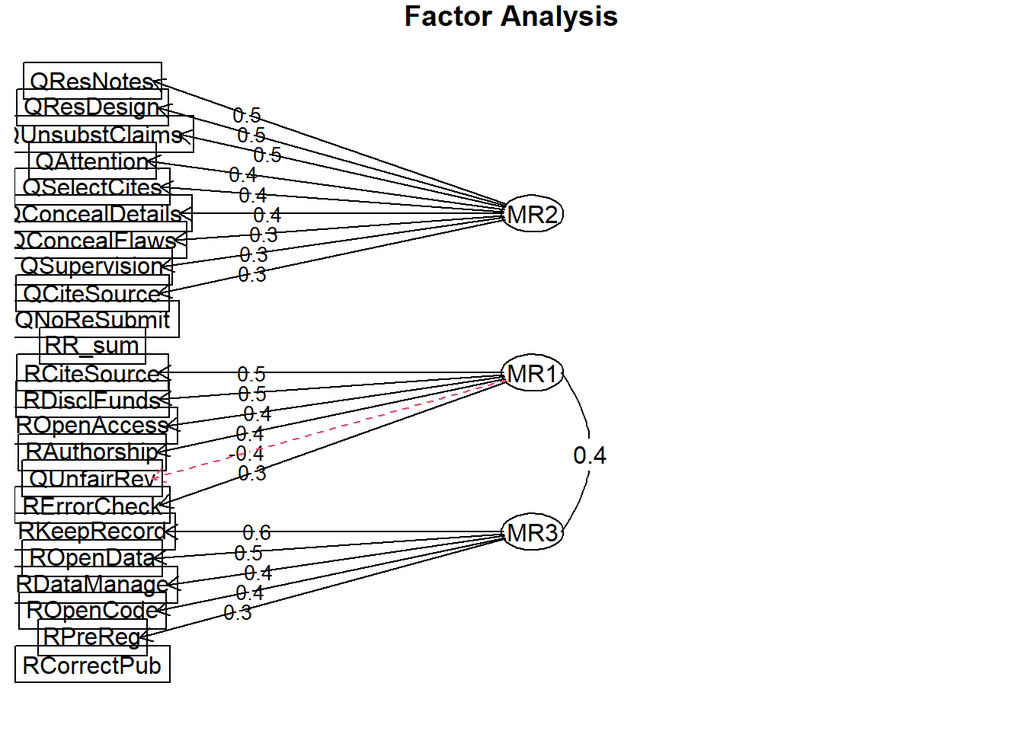

```r
fa.diagram(efa.fit.3)
```

The factor path plot shows the structure of the model with three factors. `MR2` is the QRP factor, `MR1` is one RRP factor (RRP.1) and `MR3` is the other RRP factor (RRP.2). In this plot, the variable `QUnfairRev` is an indicator of RRP.1. The loading of `QUnfairRev` is -0.35 on RRP.1 and is 0.2 on QRP.

The loading of `RCorrectPub` is 0.19 on both RRP.1 and RRP.2. To follow the assumption of correlated residuals between `RCorrectPub` and `RErrorCheck`, I treat `RCorrectPub` as an indicator of RRP.1.

# Perform confirmatory factor analysis with three factors

```r
Model.3 <- '#latent variable definition
            QRP =~ QAttention + QSupervision + QResDesign
                 + QUnsubstClaims + QCiteSource + QResNotes + QConcealDetails
                 + QNoReSubmit + QConcealFlaws + QSelectCites
                 + RR_sum
            RRP.1 =~ RDisclFunds + RCorrectPub + RAuthorship  + ROpenAccess
                   + RCiteSource  + RErrorCheck + QUnfairRev
            RRP.2 =~ RKeepRecord + RDataManage + ROpenData + ROpenCode
                   + RPreReg
            #variance and covariance
            RDisclFunds ~~ RAuthorship
            RCorrectPub ~~ RErrorCheck
            ROpenData ~~ ROpenCode
            RRP.1 ~~ RRP.2


'
fit.model.3 <- cfa(Model.3, data = complete(d50[[1]]), estimator = "WLSMV")
summary(fit.model.3, fit.measures = TRUE)
```

```
## lavaan 0.6-9 ended normally after 66 iterations
##
##   Estimator                                       DWLS
##   Optimization method                           NLMINB
##   Number of model parameters                        52
##
##   Number of observations                          6813
##
## Model Test User Model:
##                                               Standard      Robust
##   Test Statistic                              3512.067    3762.334
##   Degrees of freedom                               224         224
##   P-value (Chi-square)                           0.000       0.000
##   Scaling correction factor                                  0.942
##   Shift parameter                                           35.549
##        simple second-order correction
##
## Model Test Baseline Model:
##
##   Test statistic                             23249.483   14902.057
##   Degrees of freedom                               253         253
##   P-value                                        0.000       0.000
##   Scaling correction factor                                  1.570
##
## User Model versus Baseline Model:
##
##   Comparative Fit Index (CFI)                    0.857       0.758
##   Tucker-Lewis Index (TLI)                       0.839       0.727
##
##   Robust Comparative Fit Index (CFI)                            NA
##   Robust Tucker-Lewis Index (TLI)                               NA
##
## Root Mean Square Error of Approximation:
##
##   RMSEA                                          0.046       0.048
##   90 Percent confidence interval - lower         0.045       0.047
##   90 Percent confidence interval - upper         0.048       0.050
##   P-value RMSEA <= 0.05                          1.000       0.987
##
##   Robust RMSEA                                                  NA
```

[output cut: 69 more lines]

```
##    .RDisclFunds       2.648    0.069   38.423    0.000
##    .RCorrectPub       5.147    0.045  113.959    0.000
##    .RAuthorship       2.362    0.050   47.247    0.000
##    .ROpenAccess       2.624    0.049   53.663    0.000
##    .RCiteSource       0.817    0.037   22.327    0.000
##    .RErrorCheck       1.106    0.037   29.781    0.000
##    .QUnfairRev        0.331    0.022   15.093    0.000
##    .RKeepRecord       2.543    0.050   51.045    0.000
##    .RDataManage       2.221    0.060   37.112    0.000
##    .ROpenData         2.260    0.062   36.312    0.000
##    .ROpenCode         3.300    0.055   59.473    0.000
##    .RPreReg           3.535    0.053   66.509    0.000
##     QRP               0.258    0.023   11.266    0.000
##     RRP.1             0.583    0.049   11.976    0.000
##     RRP.2             0.613    0.044   14.007    0.000
```

The CFI is 0.86.

# Five modifications to improve Model 3

```r
modificationindices(fit.model.3, sort. = TRUE, maximum.number = 5)
```

```
##             lhs op         rhs      mi    epc sepc.lv sepc.all sepc.nox
## 214   QResNotes ~~ RKeepRecord 354.961 -0.612  -0.612   -0.298   -0.298
## 56          QRP =~ RDisclFunds 270.398  0.817   0.415    0.231    0.231
## 62          QRP =~  QUnfairRev 220.614  0.306   0.156    0.253    0.253
## 323 ROpenAccess ~~   ROpenCode 200.256  0.633   0.633    0.215    0.215
## 194 QCiteSource ~~ RCiteSource 192.991 -0.162  -0.162   -0.321   -0.321
```

```r
Model.3.modi <- '#latent variable definition
            QRP =~ QAttention + QSupervision + QResDesign
                 + QUnsubstClaims + QCiteSource + QResNotes + QConcealDetails
                 + QNoReSubmit + QConcealFlaws + QSelectCites
                 + RR_sum
                 + RDisclFunds + QUnfairRev
            RRP.1 =~ RDisclFunds + RCorrectPub + RAuthorship  + ROpenAccess
                   + RCiteSource  + RErrorCheck + QUnfairRev
            RRP.2 =~ RKeepRecord + RDataManage + ROpenData + ROpenCode
                   + RPreReg
            #variance and covariance
            RDisclFunds ~~ RAuthorship
            RCorrectPub ~~ RErrorCheck
            ROpenData ~~ ROpenCode
            RRP.1 ~~ RRP.2
            QResNotes ~~ RKeepRecord
            ROpenAccess ~~ ROpenCode
            QCiteSource ~~ RCiteSource

'

fit.model.3.modi <- cfa(Model.3.modi, data = complete(d50[[1]]), estimator = "WLSMV")
summary(fit.model.3.modi, fit.measures = TRUE)
```

```
## lavaan 0.6-9 ended normally after 74 iterations
##
##   Estimator                                       DWLS
##   Optimization method                           NLMINB
##   Number of model parameters                        57
##
##   Number of observations                          6813
##
## Model Test User Model:
##                                               Standard      Robust
##   Test Statistic                              2337.699    2592.224
##   Degrees of freedom                               219         219
##   P-value (Chi-square)                           0.000       0.000
##   Scaling correction factor                                  0.913
##   Shift parameter                                           31.596
##        simple second-order correction
##
## Model Test Baseline Model:
##
##   Test statistic                             23249.483   14902.057
##   Degrees of freedom                               253         253
##   P-value                                        0.000       0.000
##   Scaling correction factor                                  1.570
##
## User Model versus Baseline Model:
##
##   Comparative Fit Index (CFI)                    0.908       0.838
##   Tucker-Lewis Index (TLI)                       0.894       0.813
##
##   Robust Comparative Fit Index (CFI)                            NA
##   Robust Tucker-Lewis Index (TLI)                               NA
##
## Root Mean Square Error of Approximation:
##
##   RMSEA                                          0.038       0.040
##   90 Percent confidence interval - lower         0.036       0.039
##   90 Percent confidence interval - upper         0.039       0.041
##   P-value RMSEA <= 0.05                          1.000       1.000
##
##   Robust RMSEA                                                  NA
```

[output cut: 77 more lines]

```
##    .RDisclFunds       2.184    0.074   29.594    0.000
##    .QUnfairRev        0.324    0.021   15.495    0.000
##    .RCorrectPub       5.156    0.044  116.637    0.000
##    .RAuthorship       2.337    0.051   45.445    0.000
##    .ROpenAccess       2.702    0.048   56.303    0.000
##    .RCiteSource       0.844    0.037   22.869    0.000
##    .RErrorCheck       1.123    0.037   30.266    0.000
##    .RKeepRecord       2.568    0.049   52.110    0.000
##    .RDataManage       2.174    0.061   35.575    0.000
##    .ROpenData         2.236    0.063   35.512    0.000
##    .ROpenCode         3.379    0.054   62.502    0.000
##    .RPreReg           3.520    0.053   66.230    0.000
##     QRP               0.271    0.023   11.647    0.000
##     RRP.1             1.287    0.089   14.513    0.000
##     RRP.2             0.588    0.043   13.722    0.000
```

The CFI is now 0.91.